# Survey sampling and R

Thomas Lumley

6-7 July 2016

# Introductions

Thomas Lumley

Developer of R survey package

Applied research in cardiovascular epi/genetics

**Introduce yourselves (briefly). What do you want to get from the course**

# Outline

**Today**

- Basic ideas of complex survey sampling
- Graphics
- Regression modelling of survey data

**Tomorrow**

- Calibration of weights to the population or cohort
- Exploring the *Survey of Adult Skills*
- Larger datasets: database-backed designs, `sqlsurvey`

[Including chunks of time for you to work on examples that we then discuss].

# Important Notice

Please ask questions.

That’s the benefit of having me here rather than just a pile of papers.

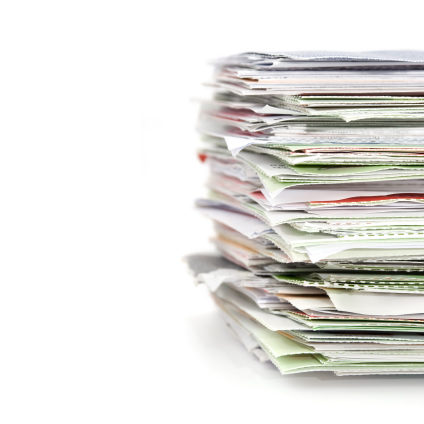

# Survey sampling

Three basic concepts

- stratification
- clustering
- unequal sampling

# Stratification

A sample of 1000 people from New Zealand would on average contain

- 141 people of Māori ethnicity
- 859 non-Māori

but the actual numbers would vary.

Part of the variance of any statistic computed from the sample comes from the variation in the number of people from each ethnicity

The mean of a sample with 160 Māori will be different from a sample with only 110

# Stratification

If we can fix the number of people sampled in each ethnicity (region, agegroup, etc), we can eliminate between-ethnicity differences from the variance of our statistics, increasing precision. This is called a **stratified sample**, the regions are **strata**

Taking a stratified sample is possible only if we have a population list that includes the stratum for each person. (“sampling frame”)

The extra precision comes from using the extra information in this population list.

Stratification **always** decreases variance, perhaps not by very much.

*[Taking a subset of a survey breaks stratification: eg, you didn’t constrain the number of Māori sampled from the Auckland region, so you don’t get the (full) benefit of stratification looking just at the Auckland region]*

# Clustering

If a survey involves a physical visit to each participant, it is less expensive to sample people who are physically close

- homes in the same neighbourhood
- students in the same classroom
- workers in the same factory
- medical records in the same hospital
- ballots at the same voting site

We often sample a small number of clusters and then sample people from each cluster.

Cluster sampling **increases** variance for the **same sample size**, but may **reduce** variance for the **same cost**

# Unequal probabilities

Either deliberately or as a result of cluster sampling, individuals in the population may not have the same probability of being sampled

The sampling probability for each individual in the sample must be known (or estimated, when there is non-response). It is written $\pi_i$ for individual $i$.

Unequal probability sampling **increases** variance for **whole-population means**, but may **decrease** variance for **subpopulation statistics** and for **regression parameters**

# Notation

- $N$ population size
- $n$ sample size
- $\pi_i$ probability that unit $i$ would be sampled
- $\pi_{ij}$ probability that both units $i$ and $j$ would be sampled
- $w_i$ weights, usually (adjusted versions of) $\pi_i^{-1}$
- $R_i$ sampling indicator: $E[R_i]=\pi_i$

# Estimating population totals

Population total $T_X$ of $X$ is
$$T_X = \sum_{i=1}^N X_i$$

Horvitz-Thompson estimator is
$$\hat T = \sum_{i=1}^N \color{red}{\frac{R_i}{\pi_i}} X_i$$

Since $E[R_i/\pi_i]=1$, $\hat T$ is unbiased as long as $\pi_i>0$ for all units in the population (or think of $\pi_i>0$ as *defining* the population)

# Estimating variances

$$\mathrm{var}\left[ \sum_{i=1}^N \frac{R_i}{\pi_i} X_i\right]=\sum_{i,j=1}^N \frac{X_iX_j}{\pi_i\pi_j}\textrm{cov}[R_i,R_j]$$

Estimate this using observed pairs $(i,\,j)$

$$\widehat{\mathrm{var}}\left[ \sum_{i=1}^N \frac{R_i}{\pi_i} X_i\right]=\sum_{i,j=1}^N \color{red}{\frac{R_iR_j}{\pi_{ij}}}\frac{X_iX_j}{\pi_i\pi_j}\textrm{cov}[R_i,R_j]$$

# More notation

$\Delta_{ij}=\textrm{cov}[R_i,R_j]$, $\check{X_i}= X_i/\pi_i$, $\check{\Delta}_{ij}=\Delta_{ij}/\pi_{ij}$

The Horvitz–Thompson estimator:

$$\hat T_x= \sum_{i\in\textrm{sample}} \check{X}_i$$

and its variance:

$$\widehat{\textrm{var}}\left[\hat T_x\right]= \sum_{i,j\in\textrm{sample}} \check{X}_i\check{X}_j\check{\Delta}_{ij}$$

[there are simpler computational formulas in special cases]

# Estimating everything else

If a parameter $\theta$ maximises or minimises an objective function
$$T_m(\theta)=\sum_{i=1}^N m_i(\theta)=0$$

it can be estimated by maximising or minimising
$$T_m(\theta)=\sum_{i\in\textrm{sample}} \check{m}_i(\theta)=0$$

If a parameter $\theta$ solves an estimating equation

$$T_U(\theta)=\sum_{i=1}^N U_i(\theta) = 0$$

it can be estimated by solving

$$\hat T_U(\theta)=\sum_{i\in\textrm{sample}} \check{U}_i(\theta)=0$$

That is, apply sampling weights $\pi_i^{-1}$ to each term.

# Standard errors

The delta-method gives a ‘sandwich’ variance

$$\widehat{\textrm{var}}[\hat\theta] = \left(\frac{\partial T_U(\theta)}{\partial\theta}\right)^{-1}\widehat{\textrm{var}}\left[\hat T_U\right]\left(\frac{\partial T_U(\theta)}{\partial\theta}\right)^{-1}$$

[Essentially the same as the HC and HAC ‘sandwich’ variances in econometrics]

# Resampling

Analogs of the bootstrap and jackknife:

- *JK1* jackknife leaving out one cluster at a time
- *JKn* stratified version of JK1
- *BRR* split data into half, lots of times
- *bootstrap* resample clusters (several variants exist)

Usually implemented by including **replicate weights** in the data file (set a weight to 0 to omit a cluster)

# Replicates

$$\widehat{var}\left[\hat T\right] = k\sum_{r=1}^R a_r (T^*_r- \hat T)^2$$

(or use $\bar T^*$ instead of $\hat T$)

Jackknife has $ka_r\sim 1$, bootstrap and BRR have $ka_r\sim 1/R$.

As in iid sampling, jackknife doesn’t work for quantiles.

# Theory

Asymptotic theory for parametric models follows easily.

For semiparametric models, the theory is more limited, because the available limit theorems are much less general.

Everyone works as if the theory will transfer, but the mathematicians haven’t caught up yet.

# Multistage sampling

Take a sample, then take a subsample in ways that don’t depend on what other units were sampled

- Sample schools, then sample classrooms within schools
- Sample counties, then sample neighbourhoods within counties
- Sample universities, then sample academics stratified by department within each university

$$\pi_i = \Pr(\textrm{chosen at stage 1})\times\Pr(\textrm{chosen at stage 2} | \textrm{in stage 1})$$

# Multiphase sampling

Take a sample, then use the *observed data values* to guide the choice of a subsample

- Case-control sampling: sample a cohort, choose subsample stratified by case status
- Case-cohort sampling: sample a cohort, take a random subcohort, augment with cases
- Random digit dialling, then follow up only those in target groups

$$\pi^*_i = \Pr(\textrm{chosen at stage 1})\times\Pr(\textrm{chosen at stage 2} | \textrm{full stage 1 sample})$$

$\pi_i^*$ is **not** $\pi_i$, but can be used the same way to make weights.

# Multiphase variances

$$\hat T_x =\sum_{i\in\textrm{sample}} \frac{X_i}{\pi^*_i}$$

$$\textrm{var}[\hat T_x] = \textrm{var}\left[E\left[\hat T_x | \textrm{phase 1}\right]\right]+E\left[\textrm{var}\left[\hat T_x | \textrm{phase 1}\right]\right]$$

Replace expectations by weighted averages, and use sandwich variances, and this becomes tractable.

As with single-phase sampling, variances for everything except totals come from delta method.

# Population or Process

Official Statistics is often about the finite population.

Other people usually want to make inference about data-generating process, not finite population.

Technically, should be treated like a multiphase problem.

In practice, population variance is $O_p(N^{-1})$, often negligible compared to sample variance $O_p(n^{-1})$

We often treat the population infinite, and the same as the process.

# Examples: mean

The population mean $\mu$ solves
$$\sum_{i=1}^N (X_i-\mu)=0$$

The estimated mean solves
$$\sum_{i\in\textrm{sample}} w_i(X_i-\mu)=0$$

Rearranging,
$$\hat\mu_x = \frac{\hat T_x}{\sum_i w_i}=\frac{\hat T_x}{\hat N}$$

# Why not divide by N?

- $\hat N$ is what the formula gives
- It often gives better performance, because $\hat T$ and $\hat N$ correlated
- Sometimes (eg, in cluster sampling) we don’t know $N$
- When we **do** know $N$, the weights are usually *calibrated* so $\hat N=N$

# Examples: median

The population median $m$ solves

$$\sum_{i=1}^N (X_i>m)-1/2=0$$

# Examples: ratio

A population ratio $r=T_y/T_x$ solves

$$\sum_{i=1}^N Y_i-rX_i=0$$

The estimated ratio solves

$$\sum_{i\in\textrm{sample}} w_i(Y_i-rX_i)=0$$

# Limitations

This linearisation approach does not work for mixed models, because the likelihood involves covariances between observations, the score function is not a sum over $i$.

Also doesn’t work for $U$-statistics (eg, Wilcoxon rank-sum is no longer the same as Mann-Whitney $U$)

# Describing (multistage) surveys to R

- Identifiers for sampling units (at each stage, optionally)
- Identifiers for strata (at each stage, optionally)
- Weights (or sampling probabilities at each stage, or population sizes at each stage)
- Population sizes at each stage (optionally)

`svydesign()` returns a survey design object containing data and design information.

# Example: California schools

Academic Performance Index: standardised test in schools

Population: 6194 schools in California, in 757 districts.

- a cluster sample of all schools in 15 districts
- a stratified unequal sample of 100 elementary schools, 50 middle schools, 50 high schools
- a two-stage cluster sample of 40 districts and up to 5 schools from each

# Cluster sample

Using $w_i =M/m$

```r
dclus1<-svydesign(id=~dnum, fpc=~fpc, data=apiclus1)
svytotal(~enroll, dclus1)
```

```
##          total      SE
## enroll 5076846 1389984
```

# Cluster sample

Rescaling $w_i$ to sum to known $N=6194$ (calibration)

```r
dclus1r<-svydesign(id=~dnum, weights=~pw, data=apiclus1,fpc=~fpc)
svytotal(~enroll, dclus1r)
```

```
##          total     SE
## enroll 3404940 932235
```

Estimate is improved: true $T_{\textrm{enroll}}= 3811472$

# Stratified sample

```r
dstrat<-svydesign(id=~snum, strata=~stype, fpc=~fpc, data=apistrat)
svytotal(~enroll, dstrat)
```

```
##          total     SE
## enroll 3687178 114642
```

```r
dstrat<-svydesign(id=~1, strata=~stype, fpc=~fpc, data=apistrat)
svytotal(~enroll, dstrat)
```

```
##          total     SE
## enroll 3687178 114642
```

# Two-stage cluster sample

Using $w=\pi_i^{-1}=\frac{N_i}{n_i}\frac{M}{m}$

```r
dclus2<-svydesign(id=~dnum+snum, data=apiclus2,fpc=~fpc1+fpc2)
svytotal(~enroll, dclus2, na.rm=TRUE)
```

```
##          total     SE
## enroll 2639273 799638
```

Rescaling $w_i$ to sum to known $N=6194$

```r
dclus2<-svydesign(id=~dnum+snum, weights=~scaledw,
                  data=apiclus2,fpc=~fpc1+fpc2)
svytotal(~enroll, dclus2, na.rm=TRUE)
```

```
##          total     SE
## enroll 3187501 965738
```

# Summaries

```r
means <- svymean(~api00+ell+comp.imp+enroll, dclus2,na.rm=TRUE)
means
```

```
##                  mean      SE
## api00       673.09434 31.0574
## ell          26.01283  5.9533
## comp.impNo    0.31094  0.0575
## comp.impYes   0.68906  0.0575
## enroll      526.26264 80.3410
```

# Summaries

```r
coef(means)
```

```
##       api00         ell  comp.impNo comp.impYes      enroll
## 673.0943396  26.0128302   0.3109434   0.6890566 526.2626415
```

```r
SE(means)
```

```
##       api00         ell  comp.impNo comp.impYes      enroll
## 31.05737405  5.95325344  0.05752341  0.05752341 80.34098399
```

```r
vcov(means)[1:2,]
```

```
##           api00        ell comp.impNo comp.impYes    enroll
## api00  964.5605 -148.87926 -1.4057368   1.4057368 -344.9397
## ell   -148.8793   35.44123  0.1851063  -0.1851063 -125.7405
```

# Summaries

```r
svyquantile(~api00, dclus2, quantile=c(0.25,0.5,0.75),ci=TRUE)
```

```
## $quantiles
##         0.25   0.5     0.75
## api00 544.95 652.9 803.5694
##
## $CIs
## , , api00
##
##            0.25      0.5     0.75
## (lower 487.7023 575.4171 690.0000
## upper) 609.5720 755.9978 862.0273
```

# Summaries

The design objects handle subpopulations transparently

```r
svyby(~api00+ell, ~comp.imp, design=dclus2,svymean)
```

```
##     comp.imp    api00      ell se.api00   se.ell
## No        No 568.3223 29.63981 20.91484 7.424750
## Yes      Yes 717.1683 24.11468 32.79669 6.002512
```

```r
svymean(~api00, subset(dclus2, stype=="E"))
```

```
##         mean     SE
## api00 692.81 29.927
```

# Tables

```r
svytable(~comp.imp+stype,dclus1,round=TRUE)
```

```
##         stype
## comp.imp    E    M    H
##      No  1615  555  353
##      Yes 5652  707  353
```

# Tests in tables

- Pearson $X^2$ in estimated population table (Rao–Scott score test, **default**)
- Wald test for interactions (*not as good*)
- LRT in estimated population table (Rao–Scott LRT)

```r
summary(svytable(~comp.imp+stype,dclus1,round=TRUE))
```

```
##         stype
## comp.imp    E    M    H
##      No  1615  555  353
##      Yes 5652  707  353
##
##  Pearson's X^2: Rao & Scott adjustment
##
## data:  svychisq(~comp.imp + stype, design = dclus1, statistic = "F")
## F = 3.5451, ndf = 1.4294, ddf = 20.0110, p-value = 0.06135
```

# Tests in tables

```r
svychisq(~comp.imp + stype, design = dclus1,statistic="saddlepoint")
```

```
##
##  Pearson's X^2: saddlepoint approximation
##
## data:  svychisq(~comp.imp + stype, design = dclus1, statistic = "saddlepoint")
## X-squared = 9.0139, p-value = 0.06107
```

```r
svychisq(~comp.imp + stype, design = dclus1,statistic="adjWald")
```

```
##
##  Design-based Wald test of association
##
## data:  svychisq(~comp.imp + stype, design = dclus1, statistic = "adjWald")
## F = 3.5013, ndf = 2, ddf = 13, p-value = 0.06075
```

# or loglinear models

```r
a<-svyloglin(~stype+comp.imp,dclus1)
b<-update(a,~.^2)
anova(a,b)
```

```
## Analysis of Deviance Table
##  Model 1: y ~ stype + comp.imp
## Model 2: y ~ stype + comp.imp + stype:comp.imp
## Deviance= 8.376767 p= 0.07205695
## Score= 9.013874 p= 0.06168927
```

# Technical details

Tests based on the ‘working’ score or pseudo likelihood ratio do not have $\chi^2_p$ asymptotic distributions (Wald-type tests do)

Distribution is linear combination of $p$ $\chi^2_1$ distributions, with coefficients based on eigenvalues of ‘design effect’ matrix: a quadratic form in Normals.

- Traditional approximation: Satterthwaite $\chi^2_q$ where $q$ matches coefficient of variation
- Satterthwaite bad in extreme tails: saddlepoint or numerical inversion of characteristic function is better

Separately

- Using ‘denominator df’= no. PSU - no. strata helps to improve the finite-sample approximation, especially for Wald-type test